# 4 — Linear models

Machine Learning (MPA-MLR)

Tomáš Vičar

Department of Biomedical Engineering · FEEC, Brno University of Technology

2026

## 1 · One equation, two tasks

> One dot product of weights and features predicts a number or a class — everything else is the choice of loss.

## Linear models: regression vs. classification

**One output** of last lecture’s $\mathbf z = W^\top \mathbf x$ — the **score**:
$$f(\mathbf x) = \mathbf w^\top \mathbf x = w_1 x_1 + w_2 x_2 + \dots + w_d x_d$$

**Bias trick:** an **affine** $f(\mathbf x) = \mathbf w^\top \mathbf x + b$ becomes purely linear — prepend $x_0 = 1$ to $\mathbf x$, put $w_0 = b$ into $\mathbf w$:
$$\tilde{\mathbf x} = \begin{bmatrix} 1 \\ \mathbf x \end{bmatrix},
\quad
\tilde{\mathbf w} = \begin{bmatrix} b \\ \mathbf w \end{bmatrix}
\;\Rightarrow\;
f(\mathbf x) = \tilde{\mathbf w}^\top \tilde{\mathbf x}$$

We write it **with or without $b$**, whichever reads better.

**Linear regression** — keep the score
$$\hat y = \mathbf w^\top \mathbf x + b = \tilde{\mathbf w}^\top \tilde{\mathbf x} \in \mathbb R$$

**Linear classification** (2 classes) — take its sign
$$\hat y = \mathrm{sign}(\mathbf w^\top \mathbf x + b) = \mathrm{sign}(\tilde{\mathbf w}^\top \tilde{\mathbf x}) \in \{-1,+1\}$$
Decision boundary: $\mathbf w^\top \mathbf x + b = 0$

## Linear classification: visualizations

1D classification

[figure not shown]

2D classification

[figure not shown]

2D classification

[figure not shown]

1D regression

[figure not shown]

2D regression

[figure not shown]

**The same equation** everywhere:

a **line** in 1D, a **plane** in 2D, a **hyperplane** in $d$ dimensions.

Regression uses the score, classification its **sign**.

## Fit a linear model

**Data:** $\{(\mathbf x_i, y_i)\}_{i=1}^n,\; \mathbf x_i \in \mathbb R^d,\; y_i \in \mathbb R$ (regression) or $y_i \in \{-1,+1\}$ (classification)

**Prediction:** $\hat y = \mathbf w^\top \mathbf x$ or $\hat y = \mathrm{sign}(\mathbf w^\top \mathbf x)$ — the only thing to learn is $\mathbf w$.

**Training:** minimize the average loss + regularization

$$\boxed{\;
\min_{\mathbf w}\;
\underbrace{\frac{1}{n}\sum_{i=1}^n \mathcal L\big(y_i,\; \mathbf w^\top \mathbf x_i \big)}_{\text{fit the data}}
\;+\;
\underbrace{\lambda\,\Omega(\mathbf w)}_{\text{keep } \mathbf w \text{ small}}
\;}$$

**Loss** $\mathcal L$

regression: MSE, MAE

classification: SVM, perceptron, LDA, logistic (log-loss)

**Regularizer** $\Omega$

$\|\mathbf w\|_2^2$ — Ridge ($L_2$)

$\|\mathbf w\|_1$ — LASSO ($L_1$)

**Weight** $\lambda$

fit ↔︎ simplicity

(a hyperparameter)

## Loss choices for linear models

Score $z=\mathbf w^\top\mathbf x$ · regression losses depend on the **residual** $y-z$, classification losses on the **margin** $yz$ ($yz>0$ ⇔ correct).

[figure not shown]

- **MSE** $(y - z)^2$ — smooth, closed form, sensitive to outliers
- **MAE** $|y - z|$ — robust to outliers; no closed form (LP/IRLS)
- **SVM** — max-margin, *hinge* $\max(0,\,1-yz)$
- **Perceptron** — $\max(0,\,-yz)$
- **Logistic** — log-loss $\log\big(1+e^{-yz}\big)$
- **LDA** — Fisher criterion (no per-sample loss)

## 2 · Linear regression

> From a line through two points to ordinary least squares, robust fits and regularization.

## Linear regression with two points

**Model:** $y = w\,x + b$ · **two equations, two unknowns:**
$$\begin{aligned}
y_1 &= w\,x_{11} + b \\
y_2 &= w\,x_{21} + b
\end{aligned}
\quad\Longleftrightarrow\quad
\begin{bmatrix} y_1\\ y_2 \end{bmatrix}
=
\underbrace{\begin{bmatrix} 1 & x_{11}\\ 1 & x_{21} \end{bmatrix}}_{\textstyle X}
\underbrace{\begin{bmatrix} b\\ w \end{bmatrix}}_{\textstyle \tilde{\mathbf w}}
,\qquad
\mathbf y = X\,\tilde{\mathbf w}$$

**Solution:** $\boxed{\tilde{\mathbf w} = X^{-1}\mathbf y}$

**Prediction** for a new input $x_{\text{new}}$, or for many new samples in the matrix $X_{\text{new}}$:
$$\hat y_{\text{new}} = w\,x_{\text{new}} + b,
\qquad
\hat{\mathbf y}_{\text{new}} = X_{\text{new}}\,\tilde{\mathbf w}$$

[figure not shown]

**By hand** for $(1, 2)$, $(3, 5)$: $X = \begin{bmatrix} 1 & 1\\ 1 & 3 \end{bmatrix}$, $\det X = 2$, $X^{-1} = \tfrac12 \begin{bmatrix} 3 & -1\\ -1 & 1 \end{bmatrix}$, $\tilde{\mathbf w} = \tfrac12 \begin{bmatrix} 3\cdot 2 - 5\\ -2 + 5 \end{bmatrix} = \begin{bmatrix} 0.5\\ 1.5 \end{bmatrix}$

Two points → a line through both. **Three or more** → no such line: make $X\tilde{\mathbf w}$ **as close as possible** to $\mathbf y$.

## MSE linear regression (OLS)

**Ordinary least squares:** predictions $X\mathbf w$ as close as possible to $\mathbf y$ in the MSE ($L_2$) sense — the **total area of the squares**:
$$\underset{\mathbf w}{\text{minimize}}\;\; g(\mathbf w) = \sum_{i=1}^n ( \mathbf x_i^\top \mathbf w - y_i )^2
= \| X\mathbf w - \mathbf y \|_2^2$$

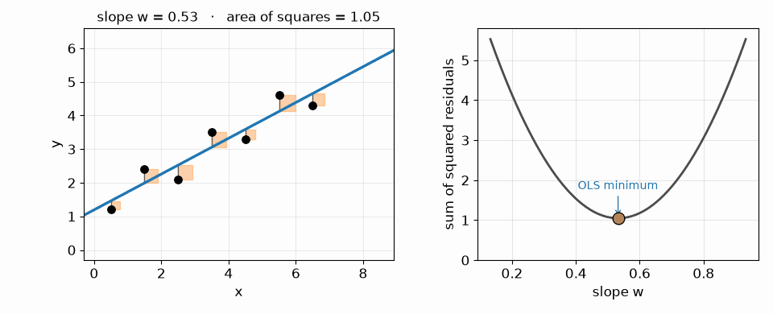

**Convex, unconstrained** → one minimum, where the gradient is zero (gradient descent would work too): $\nabla g(\mathbf w) = 2X^\top (X\mathbf w - \mathbf y) = \mathbf 0$

**Closed form:** $\boxed{\mathbf w^{*} = (X^\top X)^{-1} X^\top \mathbf y = X^\dagger \mathbf y}$ · $X^\dagger$ — the Moore–Penrose **pseudoinverse** · derivation in the appendix

## OLS by hand: three points

Data: $(0, 1)$, $(1, 2)$, $(2, 2)$ — no line passes through all three.

**1 · Build** $X$ (column of ones = bias trick) and $\mathbf y$:
$$X = \begin{bmatrix} 1 & 0\\ 1 & 1\\ 1 & 2 \end{bmatrix},\quad
\mathbf y = \begin{bmatrix} 1\\ 2\\ 2 \end{bmatrix}$$

**2 · Two small products:**
$$X^\top X = \begin{bmatrix} 3 & 3\\ 3 & 5 \end{bmatrix},\quad
X^\top \mathbf y = \begin{bmatrix} 5\\ 6 \end{bmatrix}$$

**3 · Solve** the 2 × 2 system:
$$\tilde{\mathbf w} = (X^\top X)^{-1} X^\top \mathbf y
= \tfrac{1}{6}\begin{bmatrix} 5 & -3\\ -3 & 3 \end{bmatrix}
\begin{bmatrix} 5\\ 6 \end{bmatrix}
= \begin{bmatrix} 7/6\\ 1/2 \end{bmatrix}
\;\Rightarrow\; \hat y = \tfrac{7}{6} + \tfrac12 x$$

[figure not shown]

Residuals $(-\tfrac16, \tfrac13, -\tfrac16)$, sum of squares $\tfrac16$ — the smallest any line can achieve.

The same three points with ridge ($\lambda = 1$) by hand — in the appendix

## Linear regression with MAE (LAD)

**Least absolute deviations** — the same model, the absolute instead of the squared error:
$$\underset{\mathbf w}{\text{minimize}}\;\; \sum_{i=1}^n | \mathbf x_i^\top \mathbf w - y_i|
= \| X\mathbf w - \mathbf y \|_1$$
**No closed form** — solved by optimization, e.g. as a linear program (LP formulation in the appendix).

[figure not shown]

- **Large** errors: $L_1$ ≪ $L_2$ → an outlier cannot dominate → **robust**
- **Small** errors are still penalized: $0.01^2 = 0.0001$ is practically ignored by $L_2$, not by $L_1$

$\|\mathbf x\|_2 = \|\mathbf x\| = \sqrt{\textstyle\sum_i x_i^2}$ · $\|\mathbf x\|_2^2 = \mathbf x^\top \mathbf x = \sum_i x_i^2$ · $\|\mathbf x\|_1 = \sum_i |x_i|$

## Playground: fit a line by hand

[interactive chart not shown]

Move the line. Orange **squares** = squared errors (MSE), purple **bars** = absolute errors (MAE).

slope **w** =

intercept **b** =

squares bars  
outlier (last point +6)

## Ridge vs. LASSO regularization for linear regression

**Ridge regression ($L_2$)**

$$\underset{\mathbf w}{\text{minimize}} \;
\|X\mathbf w - \mathbf y\|_2^2 + \lambda \|\mathbf w\|_2^2$$

- **Shrinks** all coefficients smoothly
- Keeps all features (**no exact zeros**)
- **Closed form:** $\mathbf w=(X^\top X+\lambda I)^{-1}X^\top \mathbf y$

**LASSO regression ($L_1$)**

$$\underset{\mathbf w}{\text{minimize}} \;
\|X\mathbf w - \mathbf y\|_2^2 + \lambda \|\mathbf w\|_1$$

- **Feature selection:** some $w_j=0$ exactly
- Robust to irrelevant features
- **No closed form** — convex optimization
- $\lambda$ — a **hyperparameter**: fit ↔︎ regularization
- LASSO: $\uparrow\lambda \rightarrow$ **fewer features** selected
- The same penalties work for other methods too (LAD, linear classifiers)
- Penalties depend on the feature **scale** → **standardize** first (second lecture)

Appendix: why the $L_1$ corner gives zeros · ridge on three points by hand

[figure not shown]

## 3 · Nonlinear features and kernels

> The model stays linear in the parameters — we only change what we feed into it.

## Polynomial regression

- **Idea:** feed powers of $x$ into the same linear model
  $$\hat y = w_0 + w_1 x + w_2 x^2 + \dots + w_m x^m$$
- **Nonlinear in $x$, linear in $\mathbf w$** → OLS and ridge work unchanged.
- Only the **matrix $X$ changes** — its columns are powers: $\ \mathbf y \approx X\mathbf w$,
  $$X = \begin{bmatrix}
  1 & x_1 & x_1^2 & \cdots & x_1^m \\
  1 & x_2 & x_2^2 & \cdots & x_2^m \\
  \vdots & \vdots & \vdots & \ddots & \vdots \\
  1 & x_n & x_n^2 & \cdots & x_n^m
  \end{bmatrix}$$

[figure not shown]

[Code example](https://github.com/tomasvicar/MLR-public/blob/master/lectures/L4/code/polynomial_regression.py) · **Explicit** expansion computes the new columns; kernels do it **implicitly** via the dual form (as kernel PCA in the third lecture).

## Effect of polynomial degree and regularization

[figure not shown]

**Two hyperparameters:** the **degree** $m$ (top row, $\lambda = 0$) and the **regularization** $\lambda$ (bottom row, $m=15$; its $\lambda = 0$ is the top-right panel).

Which one is an example of over-fitting and which one of under-fitting?

## Explicit expansion explodes

Degree 3 in 2D already has 10 features:
$$\Phi^{(3)}(\mathbf x) = [\,1,\ x_1,\ x_2,\ x_1^2,\ x_1 x_2,\ x_2^2,\ x_1^3,\ x_1^2 x_2,\ x_1 x_2^2,\ x_2^3\,]^\top$$

[figure not shown]

Monomials up to degree $m$ in $d$ variables: $\binom{d+m}{m}$

- $d=2,\ m=3$: $\binom{5}{3} = 10$
- $d=10,\ m=3$: $286$
- $d=100,\ m=3$: $176\,851$
- **RBF kernel:** infinite-dimensional $\Phi$

**Problem:** computing $\Phi(\mathbf x)$ is **expensive or impossible**.

## Primal vs. dual ridge regression

**Primal** — learn $d$ weights $\mathbf w$
$$\min_{\mathbf w}\ \|X\mathbf w-\mathbf y\|_2^{2} + \lambda \|\mathbf w\|_2^{2}$$
$$\mathbf w^{*} = (X^\top X + \lambda I)^{-1}X^\top \mathbf y$$
$$\hat y_{\text{new}} = \mathbf x_{\text{new}}^\top\mathbf w$$

**Dual** — learn $n$ coefficients $\boldsymbol\alpha$, one per sample
$$\min_{\boldsymbol\alpha}\ \tfrac{1}{2}\,\boldsymbol\alpha^\top(\color{#d62728}{X X^\top} + \lambda I)\boldsymbol\alpha - \mathbf y^\top \boldsymbol\alpha$$
$$\boldsymbol\alpha^{*} = (\color{#d62728}{X X^\top} + \lambda I)^{-1}\mathbf y,
\qquad
\mathbf w = X^\top \boldsymbol\alpha$$
$$\hat y_{\text{new}} = \textstyle\sum_{i}\alpha_i\,\color{#d62728}{\mathbf x_i^\top \mathbf x_{\text{new}}}$$

In the dual the data appear **only as dot products** (red): $XX^\top$ holds $\mathbf x_i^\top\mathbf x_j$ for all pairs, the prediction needs $\mathbf x_i^\top\mathbf x_{\text{new}}$.

[figure not shown]

Appendix: derivation · all formulas. Same problem, same prediction. **Many samples, few features** → primal; **few samples, many features** → dual.

## Kernel trick — recap from the third lecture

[figure not shown]

**Kernel** = dot product in the feature space, **without computing $\Phi$**:
$$k(\mathbf x_i, \mathbf x_j) = \Phi(\mathbf x_i)^\top \Phi(\mathbf x_j)$$

**Check by hand:** $\Phi(\mathbf x) = (x_1^2,\ x_2^2,\ \sqrt2\,x_1 x_2)$, $\ \mathbf x_i = (1, 2)$, $\mathbf x_j = (3, 1)$

- $\Phi(\mathbf x_i) = (1,\ 4,\ 2\sqrt2)$, $\ \Phi(\mathbf x_j) = (9,\ 1,\ 3\sqrt2)$
- **explicit:** $\Phi(\mathbf x_i)^\top\Phi(\mathbf x_j) = 9 + 4 + 12 = 25$
- **kernel:** $(\mathbf x_i^\top \mathbf x_j)^2 = (3 + 2)^2 = 25$ ✓
- **degree 3:** $(\mathbf x_i^\top\mathbf x_j + 1)^3$ contains all 10 monomials of $\Phi^{(3)}$ (with weights)

Works whenever the algorithm uses the samples **only through dot products** $\mathbf x_i^\top \mathbf x_j$ — its **dual form**.

Why it holds for every pair: the algebra in the appendix

## Kernel function and kernel matrix

**Common kernels:**

- **Linear:** $k(\mathbf x_i,\mathbf x_j) = \mathbf x_i^\top \mathbf x_j$
- **Polynomial:** $k(\mathbf x_i,\mathbf x_j) = (\mathbf x_i^\top \mathbf x_j + c)^p$
- **RBF (Gaussian):** $k(\mathbf x_i,\mathbf x_j) = \exp\big(-\tfrac{\|\mathbf x_i - \mathbf x_j\|^2}{2\sigma^2}\big)$

**Kernel (Gram) matrix** for $n$ samples:
$$K_{ij} = k(\mathbf x_i, \mathbf x_j), \qquad K \in \mathbb R^{n\times n}$$

$k(\mathbf x_i, \mathbf x_j)$ **replaces** $\mathbf x_i^\top \mathbf x_j$, and $K$ **replaces** $X X^\top$.

[figure not shown]

## Kernel ridge regression (KRR)

Take the dual and **swap the dot products**:

- $X X^\top \;\to\; K$
- $\mathbf x_i^\top\mathbf x_{\text{new}} \;\to\; k(\mathbf x_i, \mathbf x_{\text{new}})$

$$\boldsymbol\alpha^{*} = (K + \lambda I)^{-1}\mathbf y$$
$$\hat y_{\text{new}} = \sum_{i=1}^{n}\alpha_i\,k(\mathbf x_i, \mathbf x_{\text{new}})$$

- **Same result** as the explicit $\Phi$, **cost independent of its dimension**.
- **Price:** an $n \times n$ matrix.

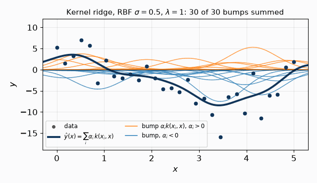

[code example](https://github.com/tomasvicar/MLR-public/blob/master/lectures/L4/code/kernel_ridge_regression.py)

## Playground: polynomial features vs. kernel ridge

[interactive chart not shown]

**Model**  
polynomial features (explicit)  
RBF kernel ridge (implicit)

true curve bumps α<sub>i</sub> k(x<sub>i</sub>, x)

The 30 points of the polynomial slides (a cubic plus noise). Polynomial: ridge on the powers of x rescaled to [−1, 1], intercept not penalized. Kernel: α = (K + λI)<sup>−1</sup> y.

## 4 · Linear classification

> Same line, different question: not how far, but on which side.

## Linearly separable data

[figure not shown]

- **Separable:** some line (a hyperplane in $d$ dimensions) puts *every* sample on its correct side.
- **Not unique:** all three lines make zero errors. Which one is best? → SVM.
- **Real data:** noise, overlap, wrong labels ⇒ almost never exactly separable.
- **Still needed** for perceptron convergence and for SVM theory.

## LDA as a classifier — recap

- **Direction:** $\mathbf w = S_W^{-1}(\boldsymbol\mu_1-\boldsymbol\mu_2)$ — class means far apart, within-class spread small (third lecture).
- **Decision:** compare the score $\mathbf w^\top\mathbf x$ with a threshold $t^{*}$; equal priors → $t^{*}$ = midpoint of the projected class means.
- **No per-sample loss:** only class means and scatter enter — unlike the other classifiers today.

[figure not shown]

Fisher criterion and the threshold with unequal priors — appendix

## MSE classifier

[figure not shown]

- **Train:** ordinary least squares on labels $y\in\{-1,+1\}$ — simple, closed form.
- **Predict:** $\hat y=\mathrm{sign}(\mathbf w^\top\mathbf x+b)$.
- **Problem:** correct points far from the boundary still pull the line — they are asked for $1$, not $3$.
- ⇒ **sensitive to outliers**, often **poor accuracy**.

## Logistic regression

**Idea:** squeeze the score $z=\mathbf w^\top\mathbf x+b$ into $(0,1)$ (or $(-1,1)$) with a sigmoid.

**Model (probabilistic):**
$$p(y=1\mid \mathbf x) = \sigma(z)=\frac{1}{1+e^{-z}}$$

**Decision rule:**
$$\hat y=\begin{cases}
1 & \text{if } \sigma(z)\ge 0.5 \;\iff\; z \ge 0\\
0 & \text{otherwise}
\end{cases}$$
equivalently $\hat y=\mathrm{sign}(z)$ for $y\in\{-1,+1\}$.

[figure not shown]

**Loss (cross-entropy / logistic)** — one function, two label codings:
$$\mathcal L_{\text{log}}(y,z)
=
\begin{cases}
-\,y\log \sigma(z) - (1-y)\log(1-\sigma(z)) & \text{for } y\in\{0,1\},\\[2pt]
\log\big(1+e^{-y z}\big) & \text{for } y\in\{-1,+1\}.
\end{cases}$$

Third lecture: logistic regression on the rings — 0.55 in 2D, 1.00 with $x_1^2+x_2^2$ added. · Appendix: the two forms agree; a gradient step by hand

## Logistic regression: a probabilistic model

Labels $y\in\{0,1\}$ (the first loss form of the previous slide); $z_i = \mathbf w^\top\mathbf x_i + b$, $p_i = \sigma(z_i)$.

- **Model:** $P(y=1\mid\mathbf x) = \sigma(\mathbf w^\top\mathbf x + b)$
- **Log-odds are linear** in $\mathbf x$:
  $$\log\frac{P(y=1\mid\mathbf x)}{P(y=0\mid\mathbf x)} = \mathbf w^\top\mathbf x + b$$
- **Likelihood** of the training labels:
  $$L(\mathbf w, b) = \prod_{i=1}^n p_i^{\,y_i}\,(1-p_i)^{1-y_i}$$
- **Maximum likelihood** ⇔ minimize $-\log L = \sum_i \mathcal L_{\text{log}}(y_i, z_i)$, the log loss

[figure not shown]

## Log loss: −log of the probability of the true class

[figure not shown]

- $\mathcal L = -\log p_{\text{true}}$, where $p_{\text{true}} = \sigma(z)$ if $y=1$ and $1-\sigma(z)$ if $y=0$
- **Far correct:** $p_{\text{true}}\to 1$ ⇒ cost ≈ 0; **far wrong:** cost ≈ $|z|$, linear
- The **cross-entropy** of classification networks (seventh lecture)
- **Gradient** of the summed loss ($y_i\in\{0,1\}$, $\tilde{\mathbf x}_i = [1;\,\mathbf x_i]$):
  $$\nabla_{\tilde{\mathbf w}} = \sum_{i=1}^n \big(\sigma(z_i) - y_i\big)\,\tilde{\mathbf x}_i$$
- $\sigma$ inside ⇒ **no closed form**; convex ⇒ **gradient descent** (first lecture)

## Logistic regression: behaviour

[figure not shown]

- **Calibrated probabilities** (under the correct model).
- **Convex** objective → gradient descent reaches the global optimum.
- **Less sensitive to outliers** than MSE: far, correct points cost ≈ 0.
- **Regularization** can be added.
- **Deep learning** uses this loss — a neural network replaces $\mathbf w^\top\mathbf x$ (seventh lecture).

## Least squares vs. logistic: far points

[interactive chart not shown]

- - - **least squares** (MSE classifier)  
—— **logistic regression**

far cluster (15 points of class +1, bottom right)

Add on click: +1 (blue ×) −1 (orange ●)  
**Click** to add a point (**shift-click** adds −1), **drag** a point to move it.

Rings: misclassified by least squares (blue) or by logistic regression (green). The far points are all *correctly* on the +1 side.

## Perceptron: model and loss

[figure not shown]

$$\hat y=\mathrm{sign}(\mathbf w^\top\mathbf x+b),\qquad y\in\{-1,+1\}$$
$$\hat y=\mathrm{sign}(\tilde{\mathbf w}^\top \tilde{\mathbf x})=\mathrm{sign}\left(\sum_{j=0}^{d} w_j x_j\right)$$

bias trick: $x_0 = 1$, $w_0 = b$

**Loss:**
$$\mathcal L_{\text{perc}}(y,\tilde{\mathbf w};\tilde{\mathbf x})=\max\big(0,\,-y\,\tilde{\mathbf w}^\top\tilde{\mathbf x}\big)$$

- **Correct side** ($y\,\tilde{\mathbf w}^\top\tilde{\mathbf x}>0$): loss $0$ — nothing to learn.
- **Wrong side:** the loss grows linearly with $-y\,\tilde{\mathbf w}^\top\tilde{\mathbf x}$.

## Perceptron: learning rule

**Loop** over $i=1,\dots,n$, repeat in epochs:
$$\text{if } y_i\,\tilde{\mathbf w}^\top \tilde{\mathbf x}_i \le 0:\quad
\tilde{\mathbf w} \leftarrow \tilde{\mathbf w} + \eta\, y_i\,\tilde{\mathbf x}_i$$

- **Misclassified** → shift $\tilde{\mathbf w}$ toward $y_i\tilde{\mathbf x}_i$; the boundary tilts toward the point.
- **Sign for free:** $y_i\in\{-1,+1\}$ flips the direction of the shift.
- **Learning rate** $\eta>0$ only rescales $\tilde{\mathbf w}$ (from $\tilde{\mathbf w}=\mathbf 0$).
- **Converges** provably only for linearly separable classes.
- **= one stochastic gradient step** on $\max(0,\,-y_i\,\tilde{\mathbf w}^\top\tilde{\mathbf x}_i)$ with step $\eta$ — gradient descent (first lecture), one sample at a time.

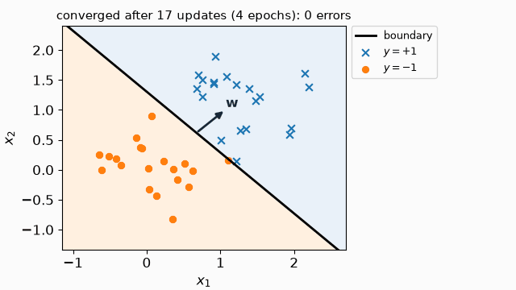

Step through it yourself — perceptron playground in the appendix

## Perceptron algorithm: code

```python
def train_perceptron(X, y, epochs):
    n, d = X.shape
    w = np.zeros(d)
    for _ in range(epochs):
        for i in range(n):
            y_hat = X[i] @ w
            if y[i] * y_hat <= 0:
                w += y[i] * X[i]
    return w
```

```python
def predict_perceptron(X, w):
    return np.sign(X @ w)
```

[figure not shown]

**Key idea:** $\mathbf w$ starts at $\mathbf 0$ and every update adds $y_i\mathbf x_i$ $\Rightarrow$ $\mathbf w=\sum_{i=1}^n \alpha_i\,\mathbf x_i$, a weighted sum (linear combination) of the samples. These $\alpha_i$ are the weights of the **dual form** — an intuitive “proof” of it. [runnable example](https://github.com/tomasvicar/MLR-public/blob/master/lectures/L4/code/perceptron.py)

## 5 · Support vector machines

> If many boundaries are correct, take the one with the widest safety zone.

## SVM intuition

- **Many** lines separate the data with **zero** training errors.
- Which one will classify **new** points best?
- **SVM:** the one with the largest **margin** — the widest empty band (“largest safe space”).
- Only the **closest points** (circled) decide where it lies.

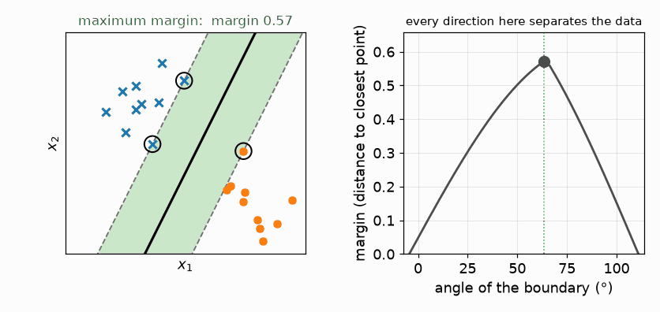

## From intuition to SVM optimization

**1 · Distance** of a point to the hyperplane $(\mathbf w,b)$: $\dfrac{|\,\mathbf w^\top \mathbf x_i + b\,|}{\|\mathbf w\|}$

**2 · Fix the scale.** $(\mathbf w,b)$ and $(2\mathbf w,2b)$ describe the same line, so we may require
$$y_i(\mathbf w^\top \mathbf x_i + b) \ge 1 \quad\text{for all } i,$$
with equality for the closest points (the **support vectors**) $\Rightarrow$ margin $= 1/\|\mathbf w\|$, band width $2/\|\mathbf w\|$.

**3 · Maximize the margin.** Maximizing $1/\|\mathbf w\|$ is the same as minimizing $\|\mathbf w\|^2$:
$$\boxed{\min_{\mathbf w,b}\ \tfrac{1}{2}\|\mathbf w\|^2 \quad \text{s.t.}\quad y_i(\mathbf w^\top \mathbf x_i+b)\ge 1,\; i=1,\dots,n}$$
A convex quadratic problem (QP) $\Rightarrow$ one global optimum.

[figure not shown]

## Hard-margin SVM: primal and dual

**Primal** — unknowns $\mathbf w, b$ (dimension $d+1$): the problem from the previous slide.

**Dual** — one unknown $\alpha_i \ge 0$ per sample ($n$ unknowns):
$$\boxed{\max_{\boldsymbol\alpha}\;
\sum_{i=1}^n \alpha_i - \tfrac{1}{2}\sum_{i,j}\alpha_i\alpha_j y_i y_j\, \color{#d62728}{\mathbf x_i^\top \mathbf x_j}
\quad\text{s.t.}\quad \sum_{i=1}^n \alpha_i y_i = 0,\;\; \boldsymbol\alpha \ge 0 }$$
$$\mathbf w=\sum_{i=1}^n \alpha_i y_i \mathbf x_i,\qquad
\hat y = \mathrm{sign}\Big(\sum_{i\in\text{SV}} \alpha_i y_i\, \color{#d62728}{\mathbf x_i^\top \mathbf x} + b\Big)$$

- The data enter **only through dot products** (red) $\to$ kernels.
- **Sparse:** $\alpha_i > 0$ only for points **on the margin**, $y_i(\mathbf w^\top \mathbf x_i + b)=1$ — the **support vectors (SV)**. The other terms are zero $\to$ only the SVs are needed to get the same line, and prediction is fast.
- Both are convex **QP** problems: standard solvers, guaranteed global optimum.

[code example](https://github.com/tomasvicar/MLR-public/blob/master/lectures/L4/code/svm_qp.py) · the dual by hand on two points — appendix

[figure not shown]

## Soft-margin SVM

Real data **overlap** $\Rightarrow$ no line satisfies all hard constraints. **Slack** $\xi_i \ge 0$ lets point $i$ violate its margin — at the price $C\xi_i$:
$$\min_{\mathbf w,b,\boldsymbol\xi}\ \tfrac{1}{2}\|\mathbf w\|^2
\;+\; C\sum_{i=1}^n \xi_i
\quad \text{s.t.}\quad
y_i(\mathbf w^\top \mathbf x_i+b)\ge 1-\xi_i,\;\;\xi_i\ge 0.$$

$C>0$ trades off margin size vs. violations:

- $\xi_i=0$: correct, **on or outside** the margin (30 points),
- $0<\xi_i\le 1$: correct but **inside** the margin (13),
- $\xi_i>1$: **misclassified** (7).

Support vectors: every point with $\xi_i > 0$ plus those exactly on the edge ($20 + 1 = 21$ of 50 here); $\sum_i \xi_i = 15.7$.

- **Still a convex QP** → standard solver, global optimum.

[figure not shown]

## Soft-margin SVM = hinge loss + L2

At the optimum every slack is as small as the constraints allow, $\xi_i = \max\big(0,\;1 - y_i(\mathbf w^\top \mathbf x_i+b)\big)$. Plugging it back removes all constraints:
$$\min_{\mathbf w,\,b}\;\;
\underbrace{\tfrac{1}{2}\|\mathbf w\|^2}_{\text{margin (regularization)}}
\;+\;
\underbrace{C \sum_{i=1}^{n} \max\big(0,\;1 - y_i(\mathbf w^\top \mathbf x_i + b)\big)}_{\text{hinge loss}}$$

- The **hinge loss** from the start of the lecture: the slack **is** the hinge.
- Score $y_i(\mathbf w^\top\mathbf x_i+b)$ $-0.5 \to \xi_i = 1.5$ (wrong side); $0.6 \to 0.4$ (inside); $2 \to 0$ (outside).
- Same form as every model today: **loss + regularization**.

[figure not shown]

## The role of C

- $\tfrac{1}{2}\|\mathbf w\|^2$: prefers a **large margin** (smaller weights).
- Hinge loss: penalizes points **inside** the margin or **misclassified**.
- **Larger** $C$: fewer violations, tighter fit — risk of **overfitting**.
- **Smaller** $C$: wider margin, more tolerance to errors — risk of **underfitting**.
- $C$ acts like $1/\lambda$ in ridge regression.
- Same data, $C$ from $0.01$ to $30$: margin $2.54 \to 0.27$, support vectors $44 \to 16$.
- The hinge loss is also used e.g. for neural networks.

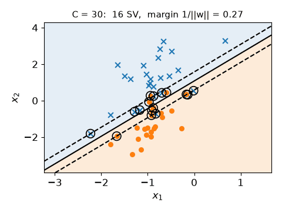

## C-SVM vs. ν-SVM

**C-SVM** (the soft margin so far) · scikit-learn `SVC`
$$\min_{\mathbf w,b,\boldsymbol\xi}\ \tfrac12\|\mathbf w\|^2 + C\sum_{i=1}^n \xi_i$$
$$\text{s.t. } y_i(\mathbf w^\top\mathbf x_i+b)\ge 1-\xi_i,\ \ \xi_i\ge 0$$

- $C > 0$, **unbounded**, scale depends on the data

**ν-SVM** · scikit-learn `NuSVC`
$$\min_{\mathbf w,b,\boldsymbol\xi,\rho}\ \tfrac12\|\mathbf w\|^2 - \nu\rho + \tfrac1n\sum_{i=1}^n \xi_i$$
$$\text{s.t. } y_i(\mathbf w^\top\mathbf x_i+b)\ge \rho-\xi_i,\ \ \xi_i\ge 0,\ \ \rho\ge 0$$

- $\nu\in(0,1]$: **margin errors** ($\xi_i>0$) $\le \nu \le$ **SVs** (as fractions)

[figure not shown]

**Same family of solutions:** every $\nu$ with $\rho > 0$ gives the boundary of some $C$ (here $\nu = 0.5$ ↔︎ $C \approx 0.11$). Details: the ν-SVM appendix.

## Kernel SVM

**Soft-margin dual:** the hard-margin dual plus one change — a box $0\le\alpha_i\le C$. Now swap the dot product for a kernel, $\color{#d62728}{\mathbf x_i^\top \mathbf x_j \;\to\; k(\mathbf x_i, \mathbf x_j)}$:
$$\boxed{\max_{\boldsymbol\alpha}\;
\sum_{i=1}^n \alpha_i
- \tfrac{1}{2}\sum_{i,j}\alpha_i\alpha_j y_i y_j \, \color{#d62728}{k( \mathbf x_i, \mathbf x_j )}
\quad\text{s.t.}\;\; \sum_i \alpha_i y_i=0,\;\;0\le\alpha_i\le C}$$

**Score** $f(\mathbf x)$ (real-valued) and **decision** $\hat y$:
$$f(\mathbf x) = \sum_{i\in\text{SV}} \alpha_i y_i\, \color{#d62728}{k(\mathbf x_i,\mathbf x)} \;+\; b,
\qquad
\hat y = \mathrm{sign}\big(f(\mathbf x)\big)$$

- **Nonlinear** decision boundary in the input space, yet the **same** optimization problem.
- Its size depends on $n$ (an $n\times n$ kernel matrix), **not** on the feature dimension — even an infinite one (RBF).
- The model is a list of support vectors with their $\alpha_i$ — no explicit $\mathbf w$.

[figure not shown]

## Kernel SVM: effect of the kernel and γ

[figure not shown]

- Same 50 points, same $C = 1$ — only the kernel changes.
- **Larger** $\gamma$ (narrower RBF) $\Rightarrow$ more complex boundary, more support vectors; **higher** degree $p$ $\Rightarrow$ more flexible boundary.
- $\gamma = 10$: 45 of 50 points are SVs — the model **memorizes** the noise.

## SVM playground

[interactive chart not shown]

Kernel:

**C** =

**γ** =

**degree p** =

Add on click: +1 (blue ×) −1 (orange ●)  
**Click** to add a point (**shift-click** adds −1), **drag** a point to move it.

The 50 points of the soft-margin slides. Thick line: boundary *f* = 0; thin grey lines: margin edges *f* = ±1; circles: support vectors. Solved in the browser by SMO (the libsvm algorithm).

## SVM and kernel SVM in practice

**Linear SVM**

- $\mathbf w$: weights (importance) of features.
- $1/\|\mathbf w\|$ = margin (half of the band width $2/\|\mathbf w\|$).
- SVs: points on or inside the margin; they alone define $\mathbf w,b$.

**Kernel SVM**

- No explicit $\mathbf w$ in the input space.
- $\alpha_i$: dual coefficients, nonzero only for SVs; larger $\alpha_i$ = more influence on the boundary.
- **Few** SVs $\Rightarrow$ sparser, simpler model; **many** SVs $\Rightarrow$ more complex boundary, higher memory cost.

**Hyperparameters to choose**

- $C$ — trade-off between margin width and training errors (or $\nu$ in the ν-SVM).
- Kernel type and its parameters:
  - polynomial: degree $p$ — larger = more complex model (overfitting),
  - RBF: $\gamma=1/(2\sigma^2)$ (inverse width) — larger = more complex model.
- Tune them on a (logarithmic) grid with cross-validation.
- **Standardize** the features first.

[code example — application](https://github.com/tomasvicar/MLR-public/blob/master/lectures/L4/code/svm_applications.py)

## 6 · Recap

> The whole chain from OLS to kernel SVM on one page and one picture — then three sets of questions to check that it holds together.

## Summary: one model, many losses

| Method | Loss $\mathcal L(y, z)$ | Regularizer | Closed form? | Primal / dual / kernel |
| --- | --- | --- | --- | --- |
| OLS | $(y-z)^2$ | — | ✓ $(X^\top X)^{-1}X^\top\mathbf y$ | primal |
| Ridge | $(y-z)^2$ | $\lambda\lVert\mathbf w\rVert_2^2$ | ✓ $(X^\top X+\lambda I)^{-1}X^\top\mathbf y$ | primal or dual |
| LASSO | $(y-z)^2$ | $\lambda\lVert\mathbf w\rVert_1$ | ✗ convex solver | primal |
| LAD | $\lvert y-z\rvert$ | — | ✗ linear program | primal |
| Kernel ridge | $(y-z)^2$ | $\lambda\lVert\mathbf w\rVert_2^2$ | ✓ $(K+\lambda I)^{-1}\mathbf y$ | kernel (dual) |
| LDA | Fisher criterion, no per-sample loss | — | ✓ $S_W^{-1}(\boldsymbol\mu_1-\boldsymbol\mu_2)$ | primal |
| MSE classifier | $(1-yz)^2$ | — | ✓ as OLS | primal |
| Logistic | $\log(1+e^{-yz})$ | optional $L_2$ / $L_1$ | ✗ gradient descent | primal |
| Perceptron | $\max(0,-yz)$ | — | ✗ update rule | primal; $\mathbf w = \sum_i \alpha_i\mathbf x_i$ |
| SVM | $\max(0,1-yz)$ | $\tfrac12\lVert\mathbf w\rVert^2$ ($C\sim1/\lambda$) | ✗ QP | primal or dual |
| Kernel SVM | $\max(0,1-yz)$ | $\tfrac12\lVert\mathbf w\rVert^2$ | ✗ QP | kernel (dual) |

Score $z = \mathbf w^\top\mathbf x + b$; regression losses use the residual $y - z$, classification losses the margin $yz$ with $y\in\{-1,+1\}$.

## Summary: five linear classifiers on one dataset

[figure not shown]

Same model $\mathrm{sign}(\mathbf w^\top\mathbf x + b)$, five losses → **different** lines. LDA and least squares are pulled by the far, correct points; losses that stop at the correct side are not.

## Recap quiz I — linear models basics

- Explain the **bias trick**. How do we rewrite $f(\mathbf x)=\mathbf w^\top\mathbf x+b$ using $\tilde{\mathbf x}$ and $\tilde{\mathbf w}$? Why is this practical?
- What is the difference between **regression** and **classification** for linear models? State the role of the decision boundary $\mathbf w^\top\mathbf x+b=0$.
- Why is **MSE** sensitive to outliers while **MAE** is more robust? Give the intuition.
- Write the generic **empirical risk minimization** form: average loss $+$ regularization. What are typical choices of $\Omega(\mathbf w)$ and their effects?
- Compare **logistic regression** with the **MSE classifier**.

## Recap quiz II — OLS, regularization, polynomials

- Derive the **closed-form solution for OLS** from the objective $g(\mathbf w)=\|X\mathbf w-\mathbf y\|_2^2$ (full steps in the appendix).
- Contrast **Ridge** ($L_2$) vs. **LASSO** ($L_1$): coefficient shrinkage, feature selection, and the existence of a closed form.
- How do you build **polynomial regression** via feature expansion? Explain why it remains linear in the parameters.
- Using a simple example, explain how the **polynomial degree** and **regularization** jointly shape the fit.

## Recap quiz III — perceptron, SVM, kernels

- Explain how the **perceptron** update implies that $\mathbf w$ is a linear combination of the training samples: $\mathbf w=\sum_i \alpha_i \mathbf x_i$.
- Define the **margin** in SVM and explain why maximizing the margin leads to minimizing $\tfrac{1}{2}\|\mathbf w\|^2$.
- Contrast **hard-margin** vs. **soft-margin** SVM. What is the role of $C$ and what do the **slack** variables $\xi_i$ represent? Why is the soft-margin SVM the same as **hinge loss + L2**?
- Interpret **support vectors** and the dual coefficients $\alpha_i$. What does *many* vs. *few* SVs mean for the model?
- Write the SVM **dual objective** and indicate where **dot products** (or kernels) appear between samples.
- Explain the **kernel trick**.
- Which **hyperparameters** do we tune in kernel SVMs (poly vs. RBF), and how do they affect the complexity of the decision boundary?
- Why is the dual/kernel approach beneficial when the feature dimension $d$ is very large or infinite?

## Appendix: Linear regression

> Optional steps behind the regression slides — the main lecture needs only the results.

## OLS: step-by-step derivation

**Expand** the squared norm:
$$g(\mathbf w) = (X\mathbf w - \mathbf y)^\top (X\mathbf w - \mathbf y)
= \mathbf w^\top X^\top X\,\mathbf w - 2\,\mathbf w^\top X^\top \mathbf y + \mathbf y^\top \mathbf y$$

**Differentiate** with $\nabla_{\mathbf w}(\mathbf w^\top A\mathbf w) = 2A\mathbf w$ ($A$ symmetric) and $\nabla_{\mathbf w}(\mathbf w^\top \mathbf c) = \mathbf c$:
$$\nabla g(\mathbf w) = 2X^\top X\,\mathbf w - 2X^\top \mathbf y = 2X^\top (X\mathbf w - \mathbf y)$$

**Set to zero** → the *normal equations*:
$$X^\top X\,\mathbf w = X^\top \mathbf y
\quad\Rightarrow\quad
\mathbf w^{*} = (X^\top X)^{-1} X^\top \mathbf y = X^\dagger \mathbf y$$

- $X^\top X$ is $d \times d$ (with the bias column $(d{+}1) \times (d{+}1)$) — its size depends on the number of **features**, not of samples
- invertible when the columns of $X$ are linearly independent; otherwise `np.linalg.pinv` still returns a least-squares solution (the one with the smallest $\|\mathbf w\|$)

[figure not shown]

The same formula for $n = 100$ points.

## Ridge by hand: the same three points

Data $(0, 1)$, $(1, 2)$, $(2, 2)$: $X^\top X = \begin{bmatrix} 3 & 3\\ 3 & 5 \end{bmatrix}$, $X^\top \mathbf y = \begin{bmatrix} 5\\ 6 \end{bmatrix}$, OLS $\tilde{\mathbf w} = \begin{bmatrix} 7/6\\ 1/2 \end{bmatrix}$.

**Ridge** with $\lambda = 1$ on the slope only (the intercept is usually not penalized):
$$\tilde{\mathbf w} = \Big(X^\top X + \begin{bmatrix} 0 & 0\\ 0 & 1 \end{bmatrix}\Big)^{-1} X^\top \mathbf y
= \tfrac19 \begin{bmatrix} 6 & -3\\ -3 & 3 \end{bmatrix}\begin{bmatrix} 5\\ 6 \end{bmatrix}
= \begin{bmatrix} 4/3\\ 1/3 \end{bmatrix}$$

The slope shrinks from $\tfrac12$ to $\tfrac13$; the intercept moves to keep the line near the data.

[figure not shown]

## LAD as a linear program

Replace every absolute value by an auxiliary variable $t_i \ge |\mathbf x_i^\top \mathbf w - y_i|$:
$$\underset{\mathbf w,\;\mathbf t}{\text{minimize}}\;\; \sum_{i=1}^n t_i
\qquad\text{s.t.}\qquad
-t_i \;\le\; \mathbf x_i^\top \mathbf w - y_i \;\le\; t_i,
\quad i = 1, \dots, n$$

- **Linear** objective and **linear** constraints → a linear program ($d + n$ variables, $2n$ inequalities)
- at the optimum every $t_i$ is pushed down to exactly $|\mathbf x_i^\top \mathbf w - y_i|$, so the minimum is the $L_1$ error
- the optimum lies at a vertex of the feasible set — for a line, some optimal LAD fit passes **through two data points**
- this is how the blue line of the MSE-vs-MAE figure is computed (`scipy.optimize.linprog`)

## Why LASSO gives exact zeros

[figure not shown]

- The penalized form equals a **constrained** one: $\min \|X\mathbf w - \mathbf y\|_2^2$ s.t. $\Omega(\mathbf w) \le t$ (each $\lambda$ has its $t$)
- The solution is where the growing loss ellipse **first touches** the allowed region
- The $L_1$ diamond has **corners on the axes** → the touch is often at a corner → some $w_j = 0$; the $L_2$ disc has no corners

## Appendix: Nonlinear features and kernels

> Optional algebra behind the kernel trick and kernel ridge regression.

## Kernel trick: the algebra

**1. Explicit feature expansion:** $\ \Phi(\mathbf x) = (x_1^2, \; x_2^2, \; \sqrt{2}\,x_1 x_2)$
$$\Phi(\mathbf x_i)^\top \Phi(\mathbf x_j)
= x_{i1}^2 x_{j1}^2 + x_{i2}^2 x_{j2}^2 + 2 x_{i1} x_{i2} x_{j1} x_{j2}$$

**2. Direct computation (kernel trick):**
$$(\mathbf x_i^\top \mathbf x_j)^2
= (x_{i1} x_{j1} + x_{i2} x_{j2})^2
= x_{i1}^2 x_{j1}^2 + x_{i2}^2 x_{j2}^2 + 2 x_{i1} x_{i2} x_{j1} x_{j2}$$

**Conclusion:** computing $\Phi(\mathbf x_i)^\top \Phi(\mathbf x_j)$ explicitly is the same as computing $(\mathbf x_i^\top \mathbf x_j)^2$ — for every pair, not only $(1,2)$ and $(3,1)$. $\Rightarrow$ the kernel function avoids the explicit high-dimensional mapping.

**Kernel matrix (Gram matrix)** for $n$ samples $\{\mathbf x_1, \dots, \mathbf x_n\}$:
$$K =
\begin{bmatrix}
k(\mathbf x_1, \mathbf x_1) & k(\mathbf x_1, \mathbf x_2) & \dots & k(\mathbf x_1, \mathbf x_n) \\
k(\mathbf x_2, \mathbf x_1) & k(\mathbf x_2, \mathbf x_2) & \dots & k(\mathbf x_2, \mathbf x_n) \\
\vdots & \vdots & \ddots & \vdots \\
k(\mathbf x_n, \mathbf x_1) & k(\mathbf x_n, \mathbf x_2) & \dots & k(\mathbf x_n, \mathbf x_n)
\end{bmatrix}$$
With the linear kernel $K = XX^\top$. A valid kernel gives a symmetric, positive semidefinite $K$ for any set of samples.

## Dual ridge regression: derivation

Start from the primal solution: $\ (X^\top X + \lambda I)\,\mathbf w = X^\top \mathbf y$

1. **Rearrange** ($\lambda > 0$):
   $$\lambda\mathbf w = X^\top(\mathbf y - X\mathbf w)
   \;\Rightarrow\;
   \mathbf w = X^\top\boldsymbol\alpha, \qquad \boldsymbol\alpha = \tfrac1\lambda(\mathbf y - X\mathbf w)$$
2. **Substitute** $\mathbf w = X^\top\boldsymbol\alpha$ into the definition of $\boldsymbol\alpha$:
   $$\lambda\boldsymbol\alpha = \mathbf y - XX^\top\boldsymbol\alpha
   \;\Rightarrow\;
   (XX^\top + \lambda I)\,\boldsymbol\alpha = \mathbf y$$
3. **Dual objective** — its gradient is zero exactly there:
   $$\underset{\boldsymbol\alpha}{\text{minimize}}\;\;
   \tfrac{1}{2}\,\boldsymbol\alpha^\top(X X^\top + \lambda I)\boldsymbol\alpha - \mathbf y^\top \boldsymbol\alpha
   \qquad
   \nabla = (XX^\top + \lambda I)\boldsymbol\alpha - \mathbf y = \mathbf 0$$

$\alpha_i$ = **residual of sample $i$ divided by $\lambda$**; the weights are a combination of the training samples.

## Primal, dual and kernel ridge: all formulas

|  | **Primal** | **Dual** | **Kernel (KRR)** |
| --- | --- | --- | --- |
| objective | $\lVert X\mathbf w-\mathbf y\rVert_2^{2} + \lambda \lVert\mathbf w\rVert_2^{2}$ | $\tfrac{1}{2}\boldsymbol\alpha^\top(X X^\top + \lambda I)\boldsymbol\alpha - \mathbf y^\top \boldsymbol\alpha$ | $\tfrac{1}{2}\boldsymbol\alpha^\top(K + \lambda I)\boldsymbol\alpha - \mathbf y^\top \boldsymbol\alpha$ |
| solution | $\mathbf w^{*} = (X^\top X + \lambda I)^{-1}X^\top \mathbf y$ | $\boldsymbol\alpha^{*} = (X X^\top + \lambda I)^{-1}\mathbf y$ | $\boldsymbol\alpha^{*} = (K + \lambda I)^{-1}\mathbf y$ |
| matrix inverted | $d \times d$ | $n \times n$ | $n \times n$ |
| one new sample | $\mathbf x_{\text{new}}^\top\mathbf w$ | $\sum_i\alpha_i\,\mathbf x_i^\top \mathbf x_{\text{new}} = \boldsymbol\alpha^\top X\,\mathbf x_{\text{new}}$ | $\sum_i\alpha_i\,k(\mathbf x_i, \mathbf x_{\text{new}})$ |
| many new samples | $X_{\text{new}}\,\mathbf w$ | $X_{\text{new}}X^\top \boldsymbol\alpha$ | $K_{\text{new}}\,\boldsymbol\alpha$ |

[Code example](https://github.com/tomasvicar/MLR-public/blob/master/lectures/L4/code/kernel_ridge_regression.py) · $X_{\text{new}}\in\mathbb R^{m\times d}$ holds $m$ new samples as rows; $(K_{\text{new}})_{ij} = k(\mathbf x_{\text{new},i}, \mathbf x_j)$ is $m \times n$. Link between primal and dual: $\mathbf w = X^\top \boldsymbol\alpha = \sum_i \alpha_i \mathbf x_i$.

## Appendix: Linear classification

> The LDA threshold with priors, the logistic gradient by hand, and a perceptron to step through.

## LDA classifier: Fisher criterion and threshold

**Fisher criterion** (maximize separation / penalize spread):
$$J(\mathbf w) =
\frac{(\tilde\mu_1-\tilde\mu_2)^2}{\tilde s_1^{\,2}+\tilde s_2^{\,2}}
=
\frac{\big(\mathbf w^\top(\boldsymbol\mu_1-\boldsymbol\mu_2)\big)^2}{\mathbf w^\top S_W \mathbf w},
\qquad S_W=S_1+S_2 ,$$
maximized by $\mathbf w = S_W^{-1}(\boldsymbol\mu_1-\boldsymbol\mu_2)$ — any nonzero multiple gives the same direction.

**Threshold with priors** $\pi_1,\pi_2$ (Gaussian classes with a shared covariance). The scale of $\mathbf w$ now matters: use the pooled covariance $\Sigma_W = S_W/(n-2)$,
$$\boxed{\;\mathbf w = \Sigma_W^{-1}(\boldsymbol\mu_1-\boldsymbol\mu_2)\;}
\qquad
\text{class 1 if } \mathbf w^\top\mathbf x > t^{*},\qquad
\boxed{\,t^{*} = \tfrac12(\boldsymbol\mu_1+\boldsymbol\mu_2)^{\top}\mathbf w \;-\; \ln\frac{\pi_1}{\pi_2}\,}$$

- **Equal priors:** $\ln 1 = 0$ → the midpoint of the projected means (the figure: 90 + 90 points).
- **Class 1 more frequent** ($\pi_1>\pi_2$): $t^{*}$ drops, so class 1 is predicted more often.
- **With** $\mathbf w = S_W^{-1}(\boldsymbol\mu_1-\boldsymbol\mu_2)$ the prior term becomes $\ln(\pi_1/\pi_2)/(n-2)$.

## Logistic regression: one gradient step by hand

**One loss, two label codings.** Since $\sigma(-z)=1-\sigma(z)$:
$$-\log\sigma(z)=\log\big(1+e^{-z}\big),\qquad -\log\big(1-\sigma(z)\big)=\log\big(1+e^{z}\big),$$
so $y=1 \leftrightarrow +1$ and $y=0 \leftrightarrow -1$ both give $\log(1+e^{-yz})$.

**Gradient for one sample** ($y\in\{0,1\}$, $z=\tilde{\mathbf w}^\top\tilde{\mathbf x}$; the main slide sums it over the samples):
$$\frac{\partial\mathcal L_{\text{log}}}{\partial\tilde{\mathbf w}}=\big(\sigma(z)-y\big)\,\tilde{\mathbf x}$$
one gradient-descent step: $\tilde{\mathbf w}\leftarrow\tilde{\mathbf w}-\eta\,(\sigma(z)-y)\,\tilde{\mathbf x}$.

**One sample:** $x=2$, $y=1$ ⇒ $\tilde{\mathbf x}=(1,\,2)$; start at $\tilde{\mathbf w}=(b,\,w)=(0,\,0)$, $\eta=1$.

1. $z=0$, $\ \sigma(z)=0.5$, $\$ loss $=\ln 2\approx 0.69$
2. gradient $=(0.5-1)\,(1,\,2)=(-0.5,\,-1)$
3. $\tilde{\mathbf w}\leftarrow(0,\,0)-(-0.5,\,-1)=(0.5,\,1)$
4. $z=0.5\cdot1+1\cdot2=2.5$, $\ \sigma(z)\approx0.92$, $\$ loss $\approx 0.08$

One step moves the probability of the true class from $0.5$ to $0.92$.

## Perceptron playground

[interactive chart not shown]

Add on click: +1 (blue ×) −1 (orange ●)  
**Click** to add a point (**shift-click** adds −1), **drag** a point to move it. Changing the data restarts from **w** = 0.

Black line: the current boundary with its normal **w**; grey dashed: the boundary before the last update; the ring marks the sample just checked (red = update, green = already correct). The 40 points are those of the animation.

## Appendix: Support vector machines

> Optional detail: the dual solved by hand, why ν bounds the margin errors and the support vectors, and six ν-SVM figures.

## Hard-margin SVM by hand: two points

$\mathbf x_1 = (1, 1)$, $y_1 = +1$ and $\mathbf x_2 = (-1, -1)$, $y_2 = -1$.

**Geometry:** the boundary is the perpendicular bisector $x_1 + x_2 = 0$; each point is at distance $\sqrt2$ from it, so the margin is $1/\|\mathbf w\| = \sqrt2$ and $\|\mathbf w\| = 1/\sqrt2$.

**Primal:** $\mathbf w = (\tfrac12, \tfrac12)$, $b = 0$ — check $y_i(\mathbf w^\top \mathbf x_i + b) = 1$ for both points; objective $\tfrac12\|\mathbf w\|^2 = \tfrac14$.

**Dual:** $\mathbf x_1^\top \mathbf x_1 = \mathbf x_2^\top \mathbf x_2 = 2$, $\mathbf x_1^\top \mathbf x_2 = -2$; the constraint $\alpha_1 y_1 + \alpha_2 y_2 = 0$ gives $\alpha_1 = \alpha_2 = \alpha$:
$$\sum_i \alpha_i - \tfrac12 \sum_{i,j} \alpha_i \alpha_j y_i y_j\, \mathbf x_i^\top \mathbf x_j
= 2\alpha - \tfrac12 \cdot 2\,(2\alpha)^2 = 2\alpha - 4\alpha^2
\;\Rightarrow\; \alpha = \tfrac14$$
$$\mathbf w = \sum_i \alpha_i y_i \mathbf x_i = \tfrac14 (1, 1) + \tfrac14 (1, 1) = (\tfrac12, \tfrac12) \quad\checkmark$$
Dual optimum $2\cdot\tfrac14 - 4\cdot\tfrac1{16} = \tfrac14$ = primal optimum (strong duality); both points are support vectors.

[figure not shown]

## ν-SVM: why ν bounds the two fractions

The primal of the main slide ($C > 0$ for the C-SVM; $\nu\in(0,1]$, $\rho \ge 0$ here). Its **dual** (Schölkopf et al., 2000):
$$\max_{\boldsymbol\alpha}\; -\tfrac12\sum_{i,j}\alpha_i\alpha_j y_i y_j\,\mathbf x_i^\top\mathbf x_j
\quad\text{s.t.}\quad 0\le\alpha_i\le\tfrac1n,\;\; \sum_i\alpha_i y_i = 0,\;\; \sum_i\alpha_i \ge \nu$$

- When $\rho > 0$ at the optimum, the last constraint is active: $\sum_i \alpha_i = \nu$.
- **Margin error** ($\xi_i > 0$: inside the margin or misclassified) $\Rightarrow$ $\alpha_i = \tfrac1n$ (KKT). So $\#\text{ME}\cdot\tfrac1n \le \sum_i\alpha_i = \nu$: at most a fraction $\nu$ of margin errors — and of training errors, which are margin errors too.
- **Support vector** $\Leftrightarrow$ $\alpha_i > 0$, and every $\alpha_i \le \tfrac1n$. So $\nu = \sum_i\alpha_i \le \#\text{SV}\cdot\tfrac1n$: at least a fraction $\nu$ of SVs.
- Dividing by $\rho$ maps the solution to a C-SVM with $C = 1/(n\rho)$ — the same family of boundaries; with $\rho = 0$ (too small $\nu$ on overlapping data) the optimum is the trivial $\mathbf w = \mathbf 0$, and the bounds say nothing.
- Kernels: replace $\mathbf x_i^\top\mathbf x_j$ by $k(\mathbf x_i, \mathbf x_j)$, as for the C-SVM.

## ν-SVM visualizations

[figure not shown]

[code example — visualization](https://github.com/tomasvicar/MLR-public/blob/master/lectures/L4/code/svm_visualization.py) · [code example — application](https://github.com/tomasvicar/MLR-public/blob/master/lectures/L4/code/svm_applications.py)